# Kammerlauf MB7574 — Auswertung

Lauf: **kammer_MB7574_20260917-182810**, ausgewertet am 18.09.2026 10:11.

## 1. Überblick

| Stufe | Luft °C | EIN s | Zyklen | Werte | R5000 | R0500 | erster Wert, Median | erster Wert, SD | erster Wert, MAD | Spanne erster Wert |
| --- | --- | --- | --- | --- | --- | --- | --- | --- | --- | --- |
| -50 abkling | -50.1 | 20 | 8 | 96 | 0 | 0 | 970.5 | 5.9 | 3.0 | 955–973 |
| -50 | -50.0 | 20 | 20 | 240 | 0 | 25 | 970.0 | 7.3 | 1.5 | 938–972 |
| +20 warm1 | 20.0 | 20 | 20 | 240 | 0 | 0 | 988.0 | 0.7 | 0.0 | 986–989 |
| -60 | -60.0 | 20 | 20 | 240 | 0 | 0 | 981.0 | 0.4 | 0.0 | 980–982 |
| -65 | -65.0 | 20 | 20 | 240 | 0 | 0 | 988.0 | 1.3 | 1.5 | 984–989 |
| -70 dauer | -70.0 | 20 | 80 | 960 | 0 | 0 | 989.0 | 97.7 | 3.0 | 522–992 |
| +20 warm2 | 20.0 | 20 | 20 | 240 | 0 | 0 | 923.0 | 7.8 | 5.2 | 906–936 |

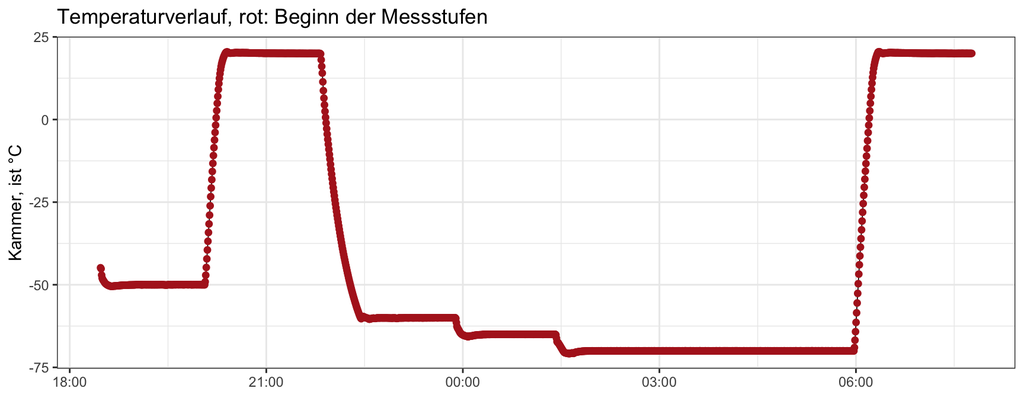

## 2. Wie gut sind die ersten Messungen?

Der erste Wert kommt etwa 0,5 s nach dem Einschalten, der zweite 0,2 s später; danach läuft die Selbstreinigung. Verglichen wird, wie stark der erste Wert von Kaltstart zu Kaltstart streut (Wiederholbarkeit) und wie weit er vom späteren Verlauf abweicht.

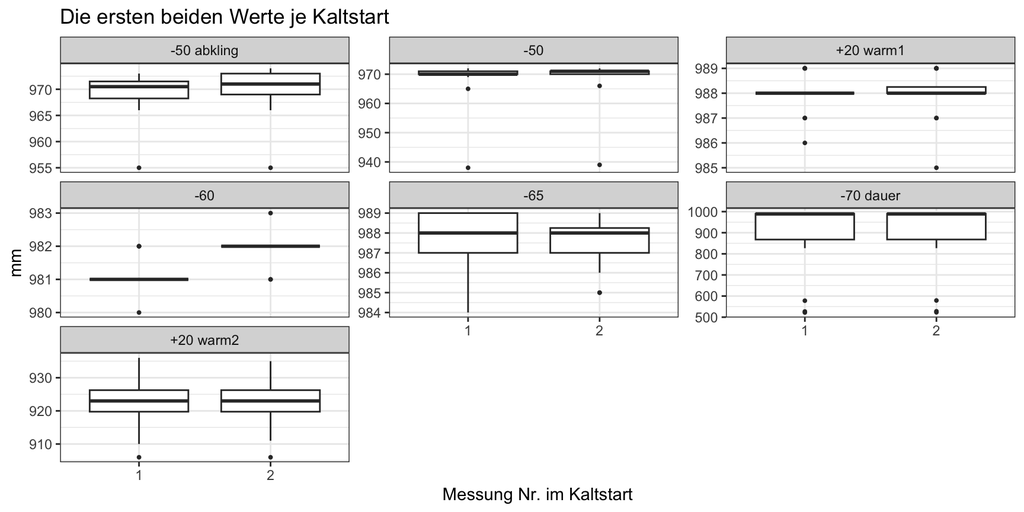

| Stufe | Paare | Differenz Median | \|Differenz\| max | SD der Differenz |
| --- | --- | --- | --- | --- |
| -50 abkling | 8 | 0.5 | 2 | 0.74 |
| -50 | 20 | 0.0 | 1 | 0.51 |
| +20 warm1 | 20 | 0.0 | 1 | 0.32 |
| -60 | 20 | 1.0 | 1 | 0.37 |
| -65 | 20 | 0.0 | 1 | 0.60 |
| -70 dauer | 80 | 0.0 | 1 | 0.50 |
| +20 warm2 | 20 | 0.0 | 1 | 0.49 |

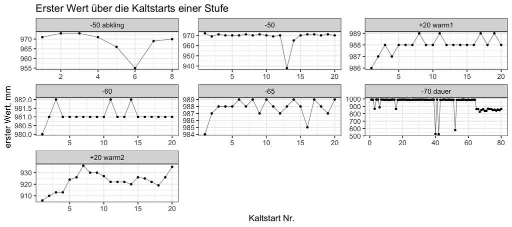

## 3. Was bringt längeres Messen?

Für jeden Kaltstart wird der Mittelwert der ersten *n* Werte gebildet. Sinkt die Streuung über die Kaltstarts mit *n*, lohnt längeres Messen; steigt der Mittelwert systematisch an, überwiegt die Eigenerwärmung.

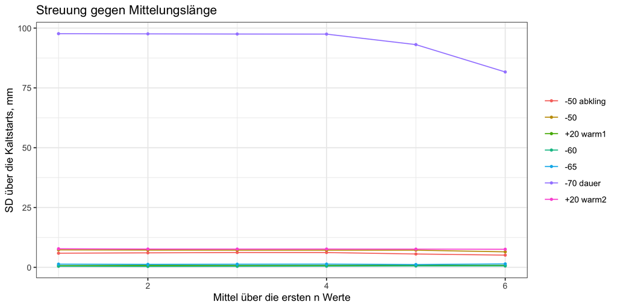

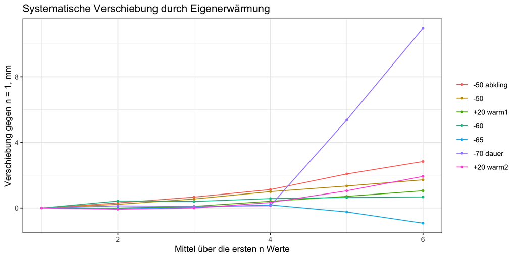

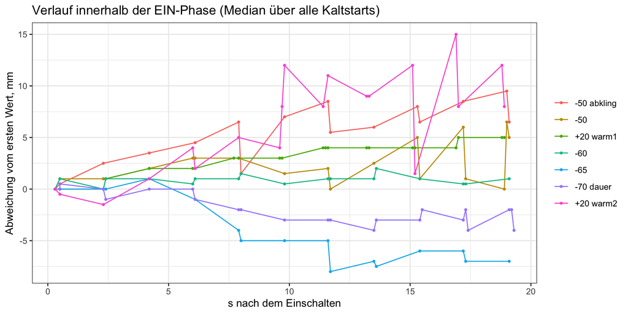

## 3b. Anlauf: Verlauf innerhalb eines Kaltstarts

Bezug ist hier der späte Teil desselben Kaltstarts (Messung 8 und später). So zeigt sich, wie weit die frühen Werte davon abweichen und ab wann ein Kaltstart stabil ist.

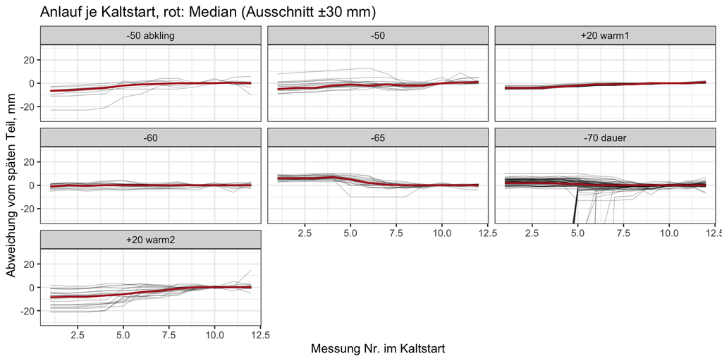

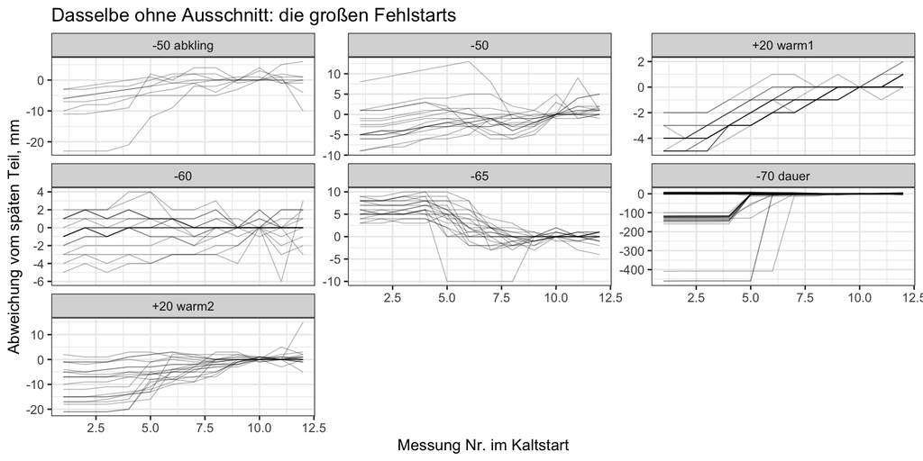

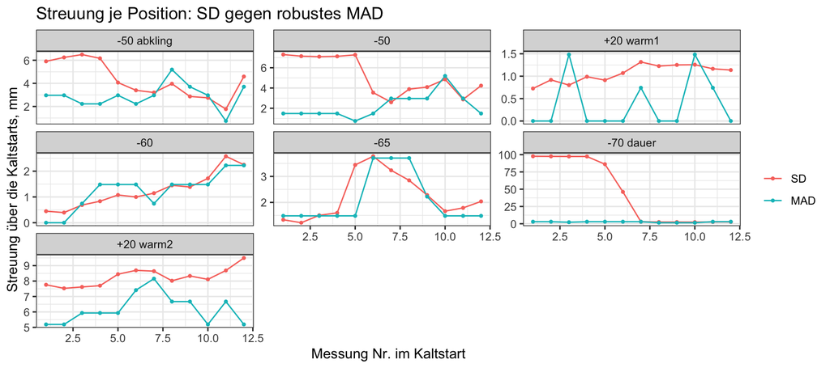

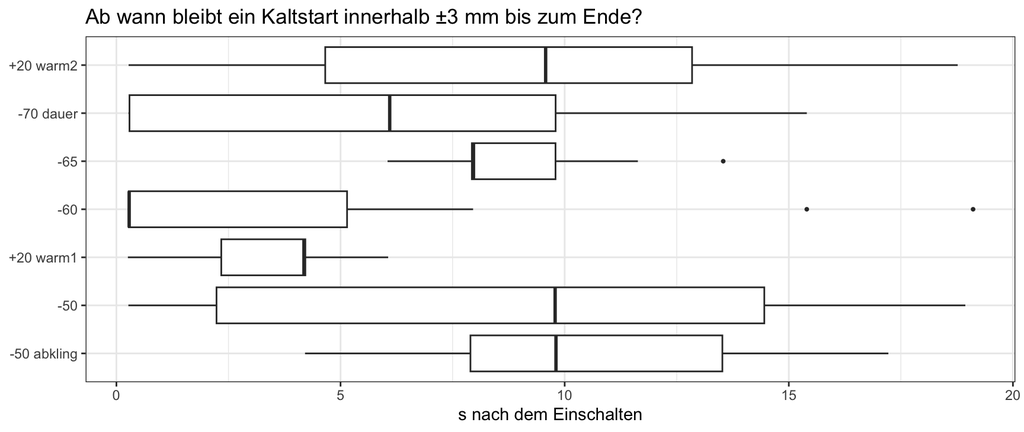

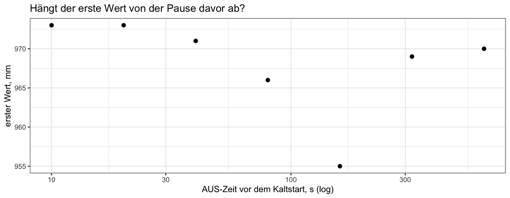

## 4. Rauschen von Messung zu Messung

| Stufe | Punkt-zu-Punkt SD (mm) | \|Sprung\| max (mm) | N |
| --- | --- | --- | --- |
| -50 abkling | 2.16 | 11 | 64 |
| -50 | 1.99 | 19 | 135 |
| +20 warm1 | 0.38 | 1 | 160 |
| -60 | 0.94 | 9 | 160 |
| -65 | 1.86 | 16 | 160 |
| -70 dauer | 25.45 | 457 | 640 |
| +20 warm2 | 2.16 | 15 | 160 |

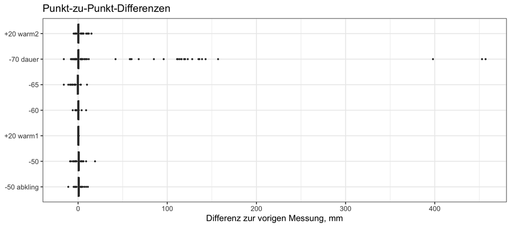

## 5. Ausreißer ganzer Messungen

Neben R5000 und R0500 kommen Werte vor, die deutlich unter dem Niveau ihres Zyklus liegen, also ein anderes Echo. Als Ausreißer zählt hier ein Wert, der mehr als 3 % vom Median seines Zyklus abweicht.

| Stufe | Werte | Ausreißer | Anteil % | Kaltstarts mit Ausreißer | Kaltstarts | kleinster Wert |
| --- | --- | --- | --- | --- | --- | --- |
| -50 abkling | 96 | 0 | 0.0 | 0 | 8 | 955 |
| -50 | 215 | 0 | 0.0 | 0 | 20 | 938 |
| +20 warm1 | 240 | 0 | 0.0 | 0 | 20 | 985 |
| -60 | 240 | 0 | 0.0 | 0 | 20 | 976 |
| -65 | 240 | 0 | 0.0 | 0 | 20 | 974 |
| -70 dauer | 960 | 108 | 11.2 | 22 | 80 | 522 |
| +20 warm2 | 240 | 0 | 0.0 | 0 | 20 | 906 |

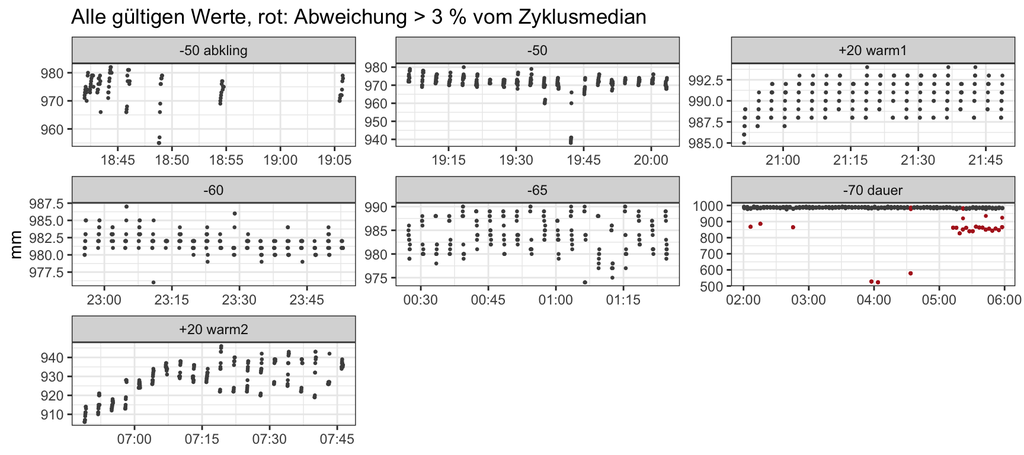

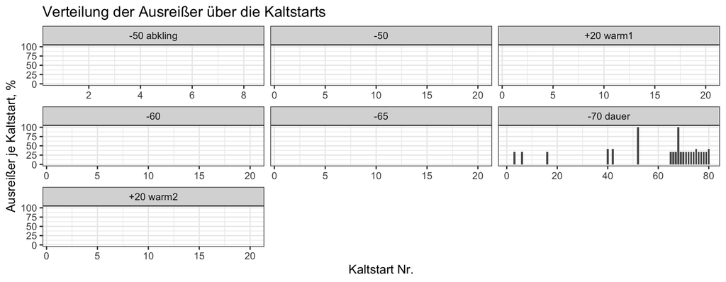

## 6. Drift und Alterung

Innerhalb einer Stufe zeigt die Steigung des ersten Werts über die Kaltstarts, ob sich etwas langsam verändert (Angleichen der Sensortemperatur, Reif, Alterung).

| Stufe | Steigung mm/Kaltstart | CI unten | CI oben | Kaltstarts |
| --- | --- | --- | --- | --- |
| -50 abkling | -1.024 | -3.204 | 1.156 | 8 |
| -50 | -0.151 | -0.758 | 0.455 | 20 |
| +20 warm1 | 0.071 | 0.021 | 0.120 | 20 |
| -60 | 0.009 | -0.028 | 0.046 | 20 |
| -65 | 0.050 | -0.058 | 0.159 | 20 |
| -70 dauer | -1.506 | -2.391 | -0.622 | 80 |
| +20 warm2 | 0.647 | 0.081 | 1.212 | 20 |

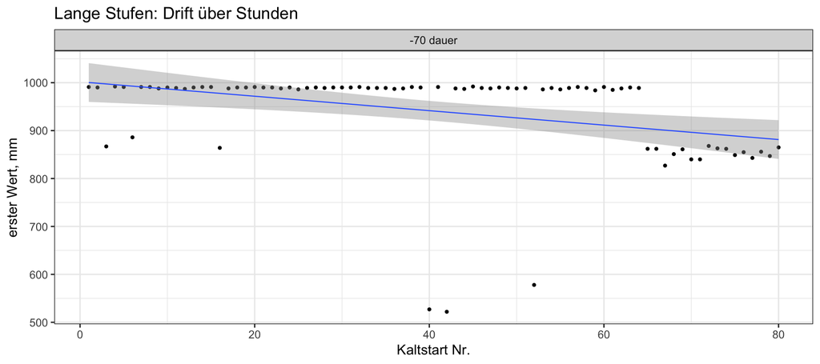

## 7. Temperaturkompensation

Aus dem ersten Wert und der Kammerluft folgt die Temperatur, mit der der Sensor gerechnet hat: `T_benutzt = T_Luft · (d_aus / d_bezug)²`, mit dem Bezugsabstand aus der Stufe warm1.

| Stufe | Luft °C | erster Wert mm | T_benutzt °C | Differenz K |
| --- | --- | --- | --- | --- |
| -50 abkling | -50.1 | 970.5 | -57.9 | -7.8 |
| -50 | -50.0 | 970.0 | -58.1 | -8.1 |
| +20 warm1 | 20.0 | 988.0 | 20.0 | 0.0 |
| -60 | -60.0 | 981.0 | -63.0 | -3.0 |
| -65 | -65.0 | 988.0 | -65.0 | 0.0 |
| -70 dauer | -70.0 | 989.0 | -69.6 | 0.4 |
| +20 warm2 | 20.0 | 923.0 | -17.3 | -37.3 |

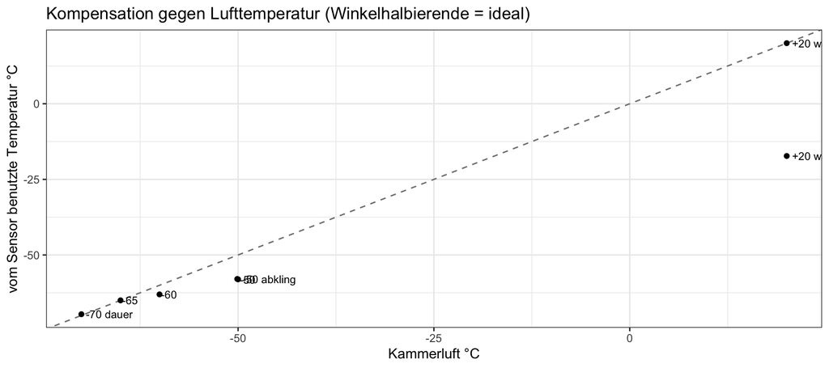

## 8. Nahbereichs-Echos R0500

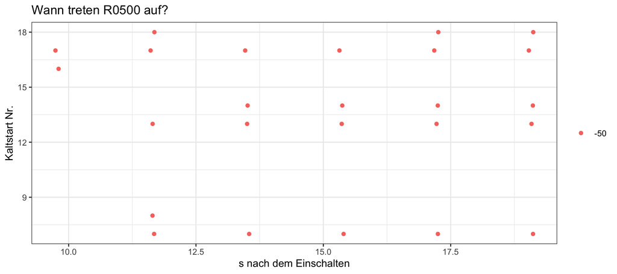

## 9. Strom

Die Ablesungen des Netzteils haben 10 mA Auflösung; in den ersten 12 s wird alle 0,5 s gelesen. Median, Mittel und Maximum unterscheiden sich, weil der Strom im Messtakt einbricht.

| Stufe | Ablesungen | Median mA | Mittel mA | p90 mA | Max mA | Anteil < 80 mA |
| --- | --- | --- | --- | --- | --- | --- |
| -50 | 460 | 100 | 90.8 | 110 | 110 | 0.135 |
| -50 abkling | 184 | 100 | 91.1 | 110 | 110 | 0.130 |
| -60 | 460 | 100 | 94.7 | 110 | 110 | 0.117 |
| -65 | 460 | 100 | 93.5 | 110 | 110 | 0.128 |
| -70 dauer | 1840 | 110 | 95.6 | 110 | 110 | 0.124 |
| +20 warm1 | 460 | 90 | 78.8 | 90 | 90 | 0.157 |
| +20 warm2 | 460 | 90 | 79.4 | 90 | 90 | 0.152 |

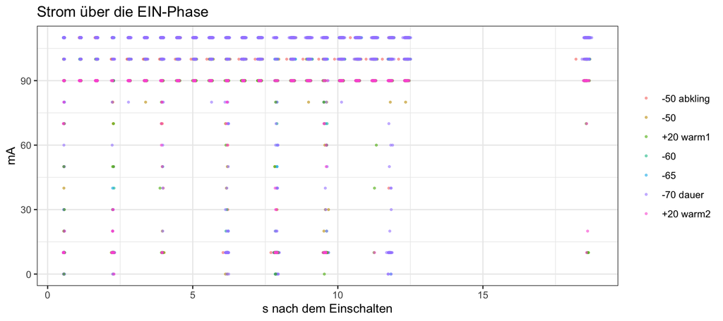